# Tipe Data Class

Python merupakan bahasa pemrograman yang berbasis Object. Object adalah suatu variabel dengan tipe data class yang tidak hanya berisi nilai atau state atau property, tetapi object juga memiliki method atau fungsi-fungsi yang melekat pada object tersebut dan dapat juga merubah nilai object tersebut.

Berikut beberapa hal yang harus diketahui untuk Pengenalan Pemrograman Berorientasi Obyek (PBO):

1. String dan List
2. Istilah dalam PBO
3. Constructor
4. Method
5. Override Method

## String dan List

Contoh tipe data class yang sudah dikenal, dan digunakan sebelumnya, adalah tipe data lists ataupun string.

Suatu variabel yang berbentuk lists ataupun string, memiliki dua buah elemen yang terkandung di dalam variabel tersebut, yaitu nilai atau yang disebut dengan state/property, serta method atau fungsi, yang dapat digunakan untuk mengolah nilai pada variabel tersebut. Method atau fungsi yang melekat pada suatu variabel dapat diakses dengan menggunakan syntax

namaObyek.NamaMethod()

**code**

berikut adalah contoh tipe data string dan list, yang memiliki nilai sekaligus method

```python
# String

dataStr='Struktur Data'
print(dataStr)
dataStr=dataStr.upper()
print(dataStr)
```

```python
# Lists
dataLs=[4,10,21]
print(dataLs)
data.append(45)
print(dataLs)
```

## Istilah dalam Pemrograman Berorientasi Obyek

Kelebihan dari bahasa pemrogaraman berbasis object, adalah bahasa tersebut menyediakan beberapa fitur agar programmer dapat membuat class sendiri yang sesuai dengan kebutuhan. Beberapa istilah dasar yang terdapat pada pemrograman berbasis object ini antara lain :

- class, tipe data yang tidak hanya berisi data tetapi juga method
- object, suatu variabel dengan tipe data class
- state, property, bagian data dari suatu class yang berisi nilai, dapat berupa string, integer, float
- method, fungsi yang melekat pada class
- constructor, fungsi yang dijalankan oleh python ketika pertama
- kali suatu objek dibuat. Method constructor ini dibuat dengan cara mendefinisikan fungsi _ init _ (dua underscore)
- self, merupakan suatu argumen atau parameter spesial agar nilai balik dari method dikembalikan ke objek itu sendiri. Argumen ini tidak perlu dipanggil (walaupun sudah didefinisikan)pada saat pemanggilan method
- instance, suatu objek yang telah dibuat
- override, mendefinisikan kembali fungsi-fungsi umum yang sudah ada, agar sesuai dengan kebutuhan programmer

## Constructor

Syntax untuk membuat suatu class, adalah sebagai berikut :

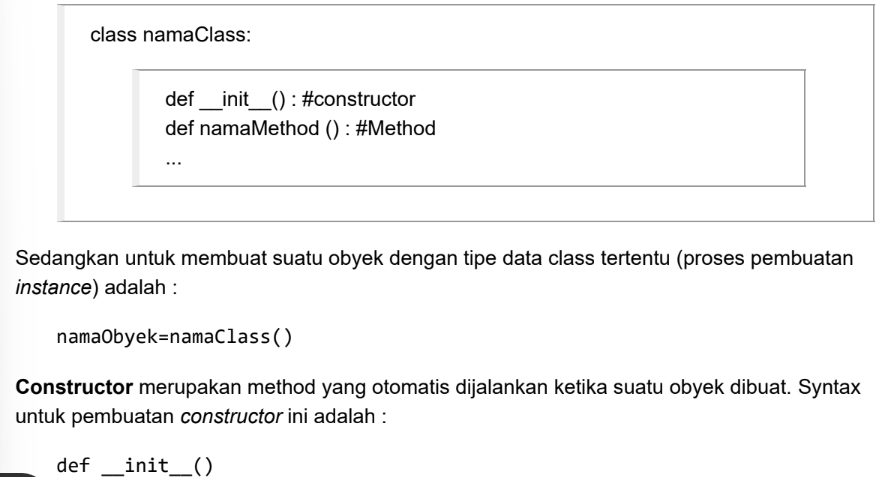

**Code**

Berikut adalah contoh pembuatan tipe data ini dimulai dari mendefinisikan class dan membuat constructor dari class tersebut. Class yang akan dibuat adalah class bilangan kompleks, dimana setiap bilangan kompleks memiliki dua buah nilai, yaitu bagian real, dan bagian imajiner.

```python
class BilanganKompleks:
    def __init__(self,a,b):
        self.real=a
        self.im=b


data=BilanganKompleks(4,6)
# untuk pengecekan tipe data dari variabel num
type(data)
```

```
__main__.BilanganKompleks
```

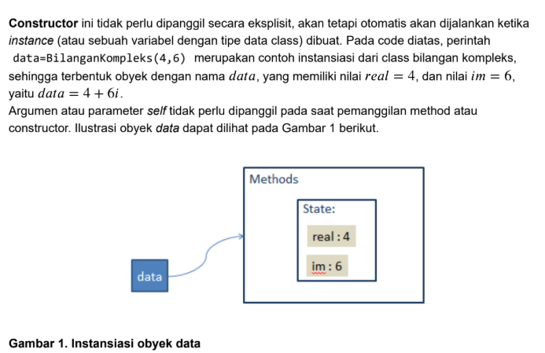

Pada contoh code sebelumnya, dilakukan syntax type(data) yaitu untuk mengetahui tipe data dari variabel data.

Misalkan isi dari data tersebut ingin ditampilkan, maka tidak bisa dilakukan dengan cara menulis syntax print seperti biasa, Jika tetap perintahkan print untuk menampilkan data tersebut, maka yang ditampilkan di layar hanyalah alamat tempat data tersebut disimpan, seperti contoh code berikut.

```python
class BilanganKompleks:
    def __init__(self,a,b):
        self.real=a
        self.im=b

data=BilanganKompleks(4,6)
print(data)
```

```
<__main__.BilanganKompleks object at 0x000001E3C8BA7770>
```

Oleh karena itu, untuk menampilkan property atau nilai yang dimiliki oleh suatu obyek, tidak dapat dilakukan dengan syntax print() seperti biasa.

Terdapat dua cara agar objek yang sudah dibuat dapat ditampilkan di layar sesuai dengan yang diinginkan, yaitu:

- Membuat method baru untuk menampilkan data
- override method standar dari sebuah class

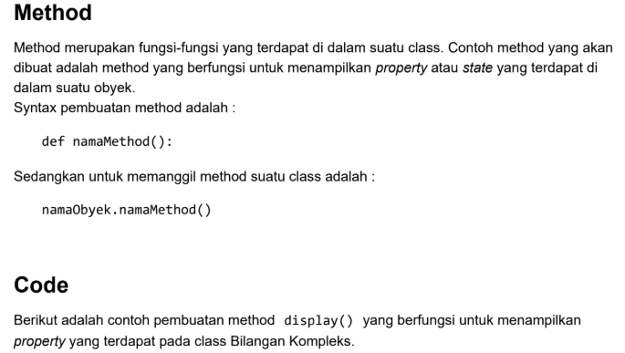

```python
class BilanganKompleks:
    def __init__(self,a,b): # constructor
        self.real=a
        self.im=b
    def display(self): # method untuk menampilkan state
        print (self.real,'+',self.im,'i')


data1=BilanganKompleks(4,6)
data1.display()
data2=BilanganKompleks(2,3)
data2.display()
```

```
4 + 6 i
2 + 3 i
```

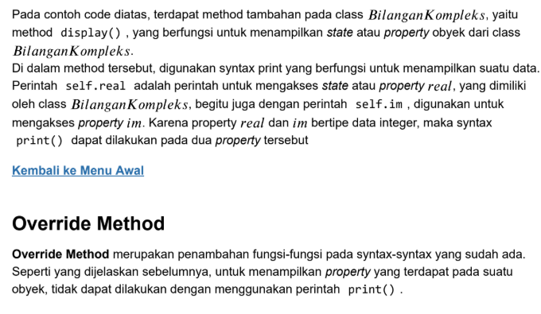

Cara pertama yang sudah dijelaskan adalah membuat method baru di dalam class, yang berfungsi untuk menampilkan property suatu class. Cara kedua adalah dengan cara override method fungsi yang sudah tersedia oleh bahasa pemrograman. Syntax yang akan dioverride adalah syntax print() . Yang perlu dilakukan agar suatu object dapat dipanggil dengan perintah print adalah object tersebut harus dirubah menjadi string. Untuk merubah suatu variabel menjadi string, maka suatu class dilengkapi dengan method **str** . Hanya saja method ini tidak bisa berfungsi secara sempurna sesuai dengan apa yang diinginkan oleh programmer, yaitu agar syntax print dapat digunakan langsung untuk menampilkan property yang terdapat pada suatu class.

**Code**

Berikut contoh override method **str** pada class BilanganKompleks

```python
class BilanganKompleks:
    def __init__(self,a,b):
        self.real=a
        self.im=b
    def display(self):
        print (self.real,"+",self.im,"i")
    def __str__(self):
        return str(self.real)+" + "+str(self.im)+" i "

data1=BilanganKompleks(4,6)
data2=BilanganKompleks(2,5)

print('Override Method')
print(data1)
print(data2)
print('Method dalam Class')
data1.display()
data2.display()
```

```
Override Method
4 + 6 i
2 + 5 i
Method dalam Class
4 + 6 i
2 + 5 i
```

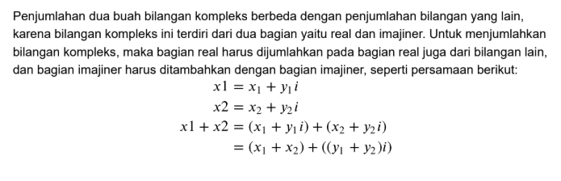

Seperti halnya fungsi untuk menampilkan property yang terdapat pada suatu class, maka untuk melakukan operasi penjumlahan ini juga dapat dilakukan dengan dua buah cara, yaitu :

- Membuat metode di dalam class untuk operasi penjumlahan
- Override method

Code

Contoh code berikut adalah pembuatan method baru di dalam class, yang berfungsi untuk menjumlahkan dua buah bilangan kompleks.

```python
class BilanganKompleks:
    def __init__(self,a,b):
        self.real=a
        self.im=b
    def display(self):
        print (self.real,'+',self.im,'i')
    def __str__(self):
        return str(self.real) + " + " + str(self.im) + " i "
    def addKompleks(self,obj):
        a=self.real+obj.real
        b=self.im+obj.im
        return BilanganKompleks(a,b)

data1=BilanganKompleks(4,6)
data2=BilanganKompleks(2,5)

jumlah=data1.addKompleks(data2)
data1.display()
data2.display()
print(jumlah)
```

```
4 + 6 i
2 + 5 i
6 + 11 i
```

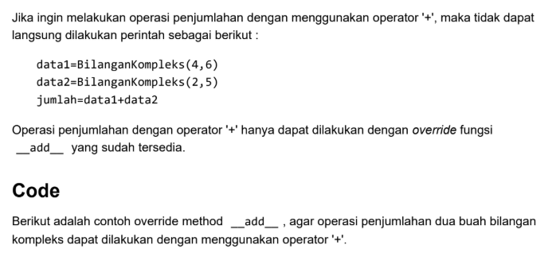

```python
class BilanganKompleks:
    def __init__(self,a,b):
        self.real=a
        self.im=b
    def display(self):
        print (self.real,'+',self.im,'i')
    def __str__(self):
        return str(self.real) + " + " + str(self.im) + " i "
    def addKompleks(self,obj):
        a=self.real+obj.real
        b=self.im+obj.im
        return BilanganKompleks(a,b)
    def __add__(self,obj):
        a=self.real+obj.real
        b=self.im+obj.im
        return BilanganKompleks(a,b)

data1=BilanganKompleks(4,6)
data1=BilanganKompleks(5,10)
jumlah=data1+data2
print(data1)
print(data2)
print(jumlah)
```

```
5 + 10 i
2 + 5 i
7 + 15 i
```

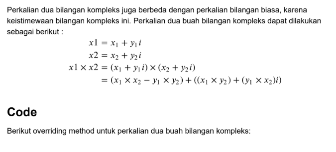

```python
class BilanganKompleks:
    def __init__(self,a,b):
        self.real=a
        self.im=b
    def display(self):
        print (self.real,'+',self.im,'i')
    def __str__(self):
        return str(self.real) + " + " + str(self.im) + " i "
    def addKompleks(self,obj):
        a=self.real+obj.real
        b=self.im+obj.im
        return BilanganKompleks(a,b)
    def __add__(self,obj):
        a=self.real+obj.real
        b=self.im+obj.im
        return BilanganKompleks(a,b)
    def __mul__(self,data):
        temp1=(self.real*data.real)-(self.im*data.im)
        temp2=(self.real*data.im)+(data.real*self.im)
        return BilanganKompleks(temp1,temp2)

a=BilanganKompleks(4,6)
b=BilanganKompleks(5,10)
c=a * b
print(a)
print(b)
print(c)
```

```
4 + 6 i
5 + 10 i
-40 + 70 i
```